# 高级API绘图库Seaborn使用

## 1. 对原图样式进行快速优化

```python
import seaborn as sns
# 使用set()方法1步设置默认样式
sns.set()
```

sns.set()采用了默认参数

```python
sns.set(context='notebook', style='darkgrid', palette='deep',
        font='sans-serif', font_scale=1, color_codes=False, rc=None)
```

其中：

- context='' 参数控制着默认的画幅大小，分别有 {paper, notebook, talk, poster} 四个值。其中，poster > talk > notebook > paper。
- style='' 参数控制默认样式，分别有 {darkgrid, whitegrid, dark, white, ticks}，你可以自行更改查看它们之间的不同。
- palette='' 参数为预设的调色板。分别有 {deep, muted, bright, pastel, dark, colorblind} 等，你可以自行更改查看它们之间的不同。
- font='' 用于设置字体
- font_scale= 设置字体大小
- color_codes= 不使用调色板而采用先前的 'r' 等色彩缩写。

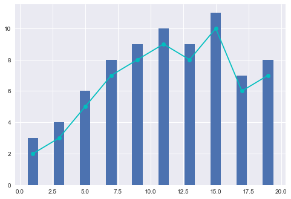

```python
import matplotlib.pyplot as plt
import seaborn as sns

x = [1, 3, 5, 7, 9, 11, 13, 15, 17, 19]
y_bar = [3, 4, 6, 8, 9, 10, 9, 11, 7, 8]
y_line = [2, 3, 5, 7, 8, 9, 8, 10, 6, 7]

sns.set()
plt.bar(x, y_bar)
plt.plot(x, y_line, '-o', color='c')

plt.show()
```

## 2. seabron.lmplot()

```python
import seaborn as sns

iris_data = sns.load_dataset('iris')  # 导入iris数据集
print(iris_data.head(10))
print(iris_data.tail(10))
```

```
   sepal_length  sepal_width  petal_length  petal_width species
0           5.1          3.5           1.4          0.2  setosa
1           4.9          3.0           1.4          0.2  setosa
2           4.7          3.2           1.3          0.2  setosa
3           4.6          3.1           1.5          0.2  setosa
4           5.0          3.6           1.4          0.2  setosa
5           5.4          3.9           1.7          0.4  setosa
6           4.6          3.4           1.4          0.3  setosa
7           5.0          3.4           1.5          0.2  setosa
8           4.4          2.9           1.4          0.2  setosa
9           4.9          3.1           1.5          0.1  setosa
     sepal_length  sepal_width  petal_length  petal_width    species
140           6.7          3.1           5.6          2.4  virginica
141           6.9          3.1           5.1          2.3  virginica
142           5.8          2.7           5.1          1.9  virginica
143           6.8          3.2           5.9          2.3  virginica
144           6.7          3.3           5.7          2.5  virginica
145           6.7          3.0           5.2          2.3  virginica
146           6.3          2.5           5.0          1.9  virginica
147           6.5          3.0           5.2          2.0  virginica
148           6.2          3.4           5.4          2.3  virginica
149           5.9          3.0           5.1          1.8  virginica
```

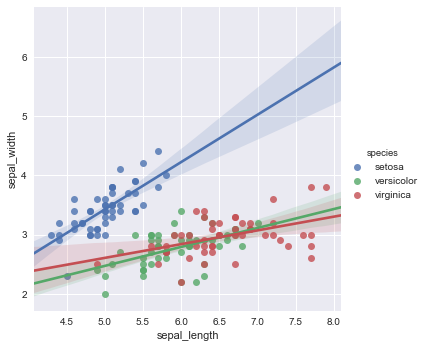

```python
# 加载数据
iris_data = sns.load_dataset('iris')

# 绘图
sns.lmplot(x='sepal_length', y='sepal_width', hue='species', data=iris_data)
plt.show()
```

sns.lmplot() 里的 x, y 分别代表横纵坐标的列名。

hue= 代表按照 species，即花的类别分类显示。

data= 自然就是关联到数据集了。

由于 Seaborn 对 Pandas 的 DataFrame 数据格式高度兼容，所以一切变得异常简单。绘制出来的图也自动带有图例，并进行了线型回归拟合，还给出了置信区间。

## 3. seaborn.PairGrid

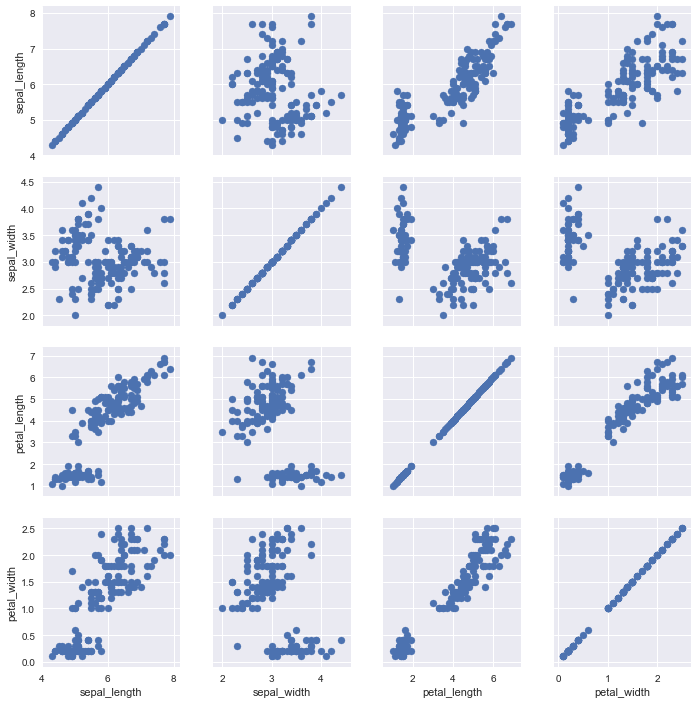

```python
sns.PairGrid(data=iris_data).map(plt.scatter)
plt.show()
```

### 用颜色区分类别

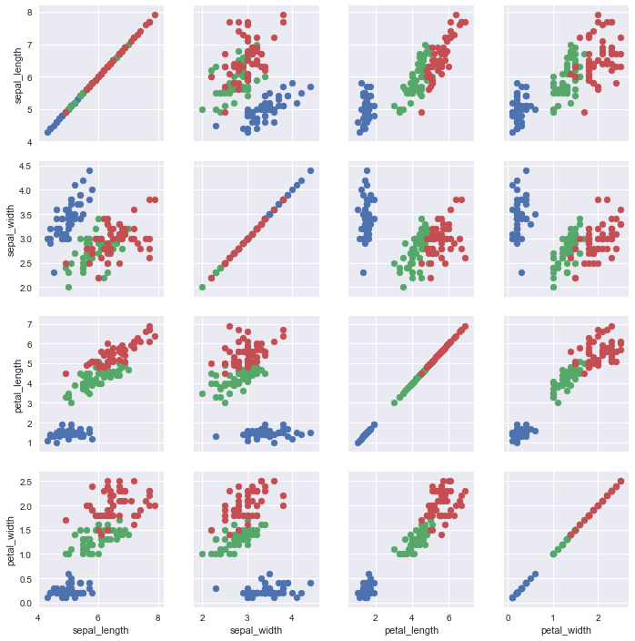

```python
sns.PairGrid(data=iris_data, hue='species').map(plt.scatter)
plt.show()
```

## 4. seaborn.JointGrid

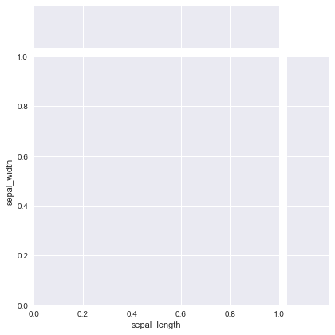

```python
sns.JointGrid(data=iris_data, x='sepal_length', y='sepal_width')
plt.show()
```

### 双变量回归拟合散点图以及单变量分布图

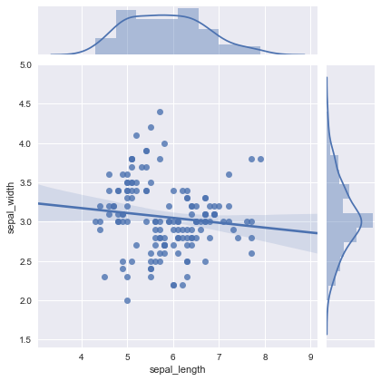

```python
sns.JointGrid(data=iris_data, x='sepal_length', y='sepal_width').plot(sns.regplot, sns.distplot)
plt.show()
```

## seaborn.kdeplot

### 单变量核密度估计曲线

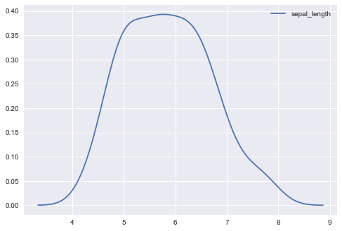

```python
sns.kdeplot(data=iris_data['sepal_length'])
plt.show()
```

可以通过 kernel= 参数设置核函数，有 {'gau' | 'cos' | 'biw' | 'epa' | 'tri' | 'triw' }等，默认为 kernel='gau'。

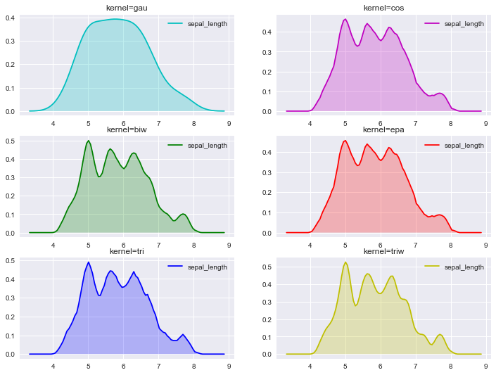

```python
plt.figure(figsize=(12,9))

ax1 = plt.subplot(3,2,1)
sns.kdeplot(data=iris_data['sepal_length'], kernel='gau', shade=True, color='c')
ax1.set_title('kernel=gau')

ax2 = plt.subplot(3,2,2)
sns.kdeplot(data=iris_data['sepal_length'], kernel='cos', shade=True, color='m')
ax2.set_title('kernel=cos')

ax3 = plt.subplot(3,2,3)
sns.kdeplot(data=iris_data['sepal_length'], kernel='biw', shade=True, color='g')
ax3.set_title('kernel=biw')

ax4 = plt.subplot(3,2,4)
sns.kdeplot(data=iris_data['sepal_length'], kernel='epa', shade=True, color='r')
ax4.set_title('kernel=epa')

ax5 = plt.subplot(3,2,5)
sns.kdeplot(data=iris_data['sepal_length'], kernel='tri', shade=True, color='b')
ax5.set_title('kernel=tri')

ax6 = plt.subplot(3,2,6)
sns.kdeplot(data=iris_data['sepal_length'], kernel='triw', shade=True, color='y')
ax6.set_title('kernel=triw')

plt.show()
```

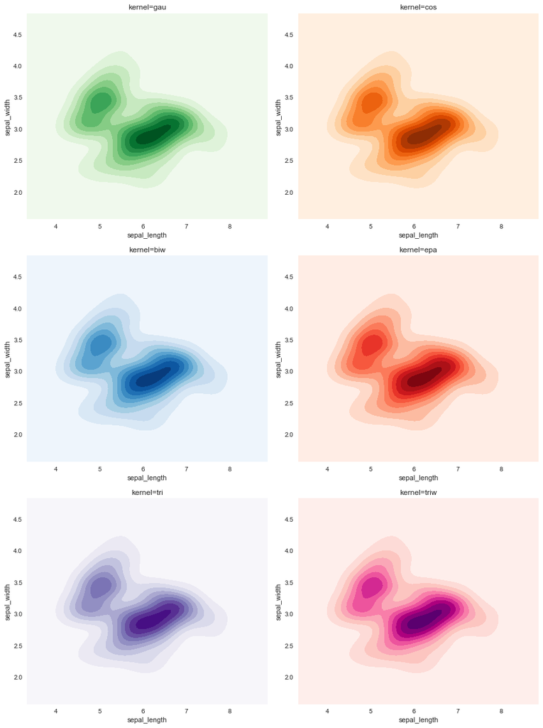

```python
plt.figure(figsize=(12,16))

ax1 = plt.subplot(3,2,1)
sns.kdeplot(data=iris_data['sepal_length'], data2=iris_data['sepal_width'], kernel='gau', shade=True, cmap='Greens')
ax1.set_title('kernel=gau')

ax2 = plt.subplot(3,2,2)
sns.kdeplot(data=iris_data['sepal_length'], data2=iris_data['sepal_width'], kernel='cos', shade=True, cmap='Oranges')
ax2.set_title('kernel=cos')

ax3 = plt.subplot(3,2,3)
sns.kdeplot(data=iris_data['sepal_length'], data2=iris_data['sepal_width'], kernel='biw', shade=True, cmap='Blues')
ax3.set_title('kernel=biw')

ax4 = plt.subplot(3,2,4)
sns.kdeplot(data=iris_data['sepal_length'], data2=iris_data['sepal_width'], kernel='epa', shade=True, cmap='Reds')
ax4.set_title('kernel=epa')

ax5 = plt.subplot(3,2,5)
sns.kdeplot(data=iris_data['sepal_length'], data2=iris_data['sepal_width'], kernel='tri', shade=True, cmap='Purples')
ax5.set_title('kernel=tri')

ax6 = plt.subplot(3,2,6)
sns.kdeplot(data=iris_data['sepal_length'], data2=iris_data['sepal_width'], kernel='triw', shade=True, cmap='RdPu')
ax6.set_title('kernel=triw')

plt.tight_layout()
plt.show()
```

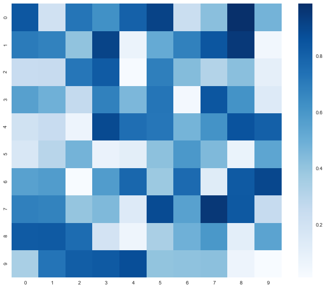

```python
import numpy as np

matrix_data = np.random.rand(10, 10)

plt.figure(figsize=(12,10))
sns.heatmap(data=matrix_data, cmap='Blues')
plt.show()
```

## 7. seaborn.clustermap

[output not shown]

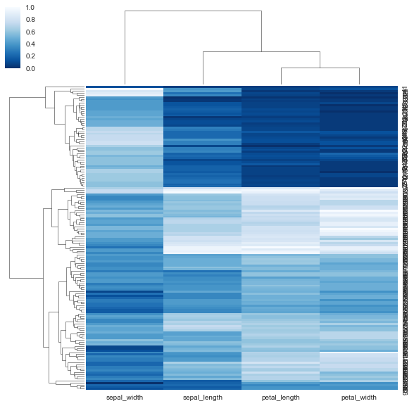

```python
sns.set(color_codes=True)

iris_data = sns.load_dataset('iris')

iris_data.pop("species")

sns.clustermap(iris_data, standard_scale=1, cmap='Blues_r')
plt.show()
```